# Session 22: Categorical relationships

First let’s load the necessary libraries and also load the data and clean them up.

```r
library(tidyverse)
```

#### Chi-squared test example

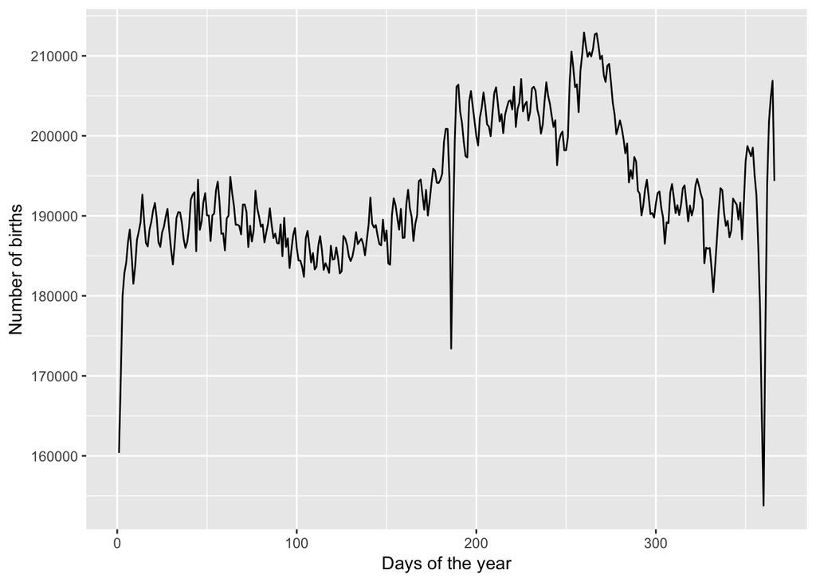

```r
#load directly from chmullig.com
bdata <- read.csv("http://chmullig.com/wp-content/uploads/2012/06/births.csv")

#filter
bdata<-bdata[(bdata$births > 1000),]
bdata$smoothbirths <- bdata$births
bdata$smoothbirths[bdata$month==2 & bdata$day==29] <- bdata$births[bdata$month==2 & bdata$day==29]*4

bdata$order <- rank(bdata$month + bdata$day/100)

#special days we might care about
bdata$flag[bdata$month==2 & bdata$day==14] <- 3
bdata$flag[bdata$month==10 & bdata$day==31] <- 1

monthstarts <- by(bdata$order, list(bdata$month), min)

ggplot(bdata,aes(order,smoothbirths)) +
  geom_line() +
  xlab('Days of the year') +
  ylab('Number of births')
```

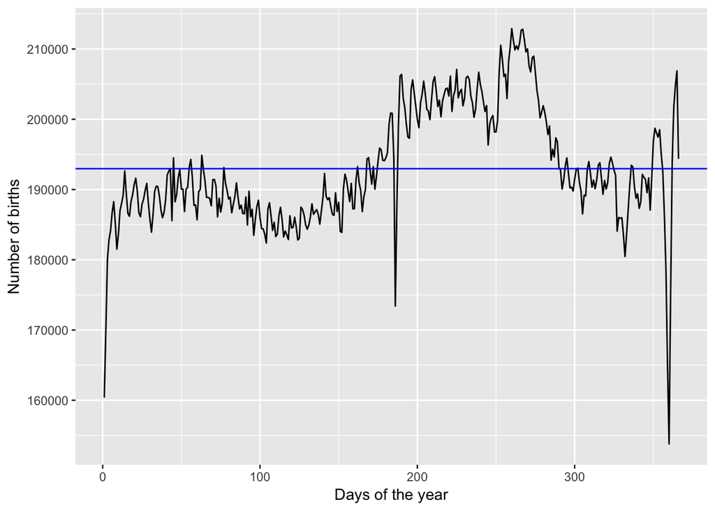

```r
# plot with mean
ggplot(bdata,aes(order,smoothbirths)) +
  geom_line() +
  xlab('Days of the year') +
  ylab('Number of births') +
  geom_hline(yintercept = mean(bdata$smoothbirths),color='blue')
```

Now compute the chi-squared test versus the expected value for all days being equal, which is simply the mean number of births per day.

```r
bdata = bdata %>%
  mutate(predicted=mean(smoothbirths)) %>%
  mutate(devianceSquared=(smoothbirths-predicted)**2)

chisqValue=sum(bdata$devianceSquared/bdata$predicted)
chisqValue
```

```
## [1] 132764.2
```

```r
chisq.test(bdata$smoothbirths)
```

```
##
##  Chi-squared test for given probabilities
##
## data:  bdata$smoothbirths
## X-squared = 132760, df = 365, p-value < 2.2e-16
```

#### Contingency table example

```r
library(NHANES)
NHANES_adult = NHANES %>% select(Diabetes,TVHrsDay) %>%
  filter(!is.na(Diabetes) & !is.na(TVHrsDay)) %>%
  mutate(TVHrsDayNumeric=recode(TVHrsDay,
                                '0_hrs' = 0,
                                '0_to_1_hr' = 0.5,
                                '1_hr' = 1,
                                '2_hr' = 2,
                                '3_hr' = 3,
                                '4_hr' = 4,
                                'More_4_hr' = 5)) %>%
  mutate(TVOver3Hrs=TVHrsDayNumeric>3)

summaryTable = NHANES_adult %>%
  group_by(Diabetes,TVOver3Hrs) %>%
  summarize(n=n()) %>%
  spread(Diabetes,n)
summaryTable
```

| TVOver3Hrs | No | Yes |
| --- | --- | --- |
| FALSE | 3509 | 225 |
| TRUE | 974 | 148 |

We can run a chi-squared test on this to test for independence.

```r
chisq.test(summaryTable[,2:3],correct=FALSE)
```

```
##
##  Pearson's Chi-squared test
##
## data:  summaryTable[, 2:3]
## X-squared = 62.46, df = 1, p-value = 2.719e-15
```

#### 2x2 test

Let’s use the data from the Stanford Open Policing Project (https://openpolicing.stanford.edu/data/) to ask whether black individuals are more likely to be searched after being pulled over by the police, compared to white individuals. We will use the data from the State of Connecticut since they are fairly small. These data were first cleaned up to remove all unnecessary data (see process_CT_data.py).

First let’s load the data and clean them up.

```r
stopData=read.table('https://rawgit.com/psych10/psych10/master/notebooks/Session22-CategoricalRelationships/CT_data_cleaned.csv',header=TRUE,sep=',') %>%
  mutate(searched=recode(search_conducted,'False'=FALSE,'True'=TRUE)) %>%
  select(-search_conducted)
```

Now let’s compute summaries for the marginal probabilities for each factor as well as the joint probabilities in the data.

```r
summaryDfRace = stopData %>%
  group_by(driver_race) %>%
  summarize(n=n(),prop=n()/nrow(stopData))
summaryDfRace
```

| driver_race | n | prop |
| --- | --- | --- |
| Black | 37463 | 0.1338863 |
| White | 242349 | 0.8661137 |

```r
summaryDfStop = stopData %>%
  group_by(searched) %>%
  summarize(n=n(),prop=n()/nrow(stopData))
summaryDfStop
```

| searched | n | prop |
| --- | --- | --- |
| FALSE | 275485 | 0.98453605 |
| TRUE | 4327 | 0.01546395 |

```r
summaryDf2way=stopData %>%
  group_by(searched,driver_race) %>%
  summarize(n=n()) %>%
  arrange(driver_race,searched)
```

Now we want to know the expected probabilities under independence, which are simply the products of each of the marginal probabilities. We can use a linear algebra trick known as an “outer product” to get this easily.

```r
expected=outer(summaryDfRace$prop, summaryDfStop$prop)*nrow(stopData)

expectedDf=data.frame(expected,driverRace = c('Black','White'))
names(expectedDf)=c('NotStopped','Stopped','driverRace')
expectedDfTidy=gather(expectedDf,searched,n,-driverRace) %>%
  arrange(driverRace,searched)


summaryDf2way = summaryDf2way %>%
  mutate(expected=NA)
summaryDf2way$expected = expectedDfTidy$n
summaryDf2way = summaryDf2way %>%
  mutate(stdSqDiff = (n - expected)**2/expected)
summaryDf2way
```

| searched | driver_race | n | expected | stdSqDiff |
| --- | --- | --- | --- | --- |
| FALSE | Black | 36244 | 36883.6739 | 11.093870 |
| TRUE | Black | 1219 | 579.3261 | 706.307991 |
| FALSE | White | 239241 | 238601.3261 | 1.714922 |
| TRUE | White | 3108 | 3747.6739 | 109.183105 |

```r
chisq=sum(summaryDf2way$stdSqDiff)
```

#### Chi-squared test

The chi-squared test quantifies the squared deviance between the observed and expected data, standardized by the expected data.

$$\chi^2 = \sum_{i,j}{\frac{(observed_{ij} - expected_{ij})^2}{expected_{ij}}}$$

Under the null hypothesis, this statistic is distributed according to a chi-squared distribution. This is what the chi-squared distribution looks like:

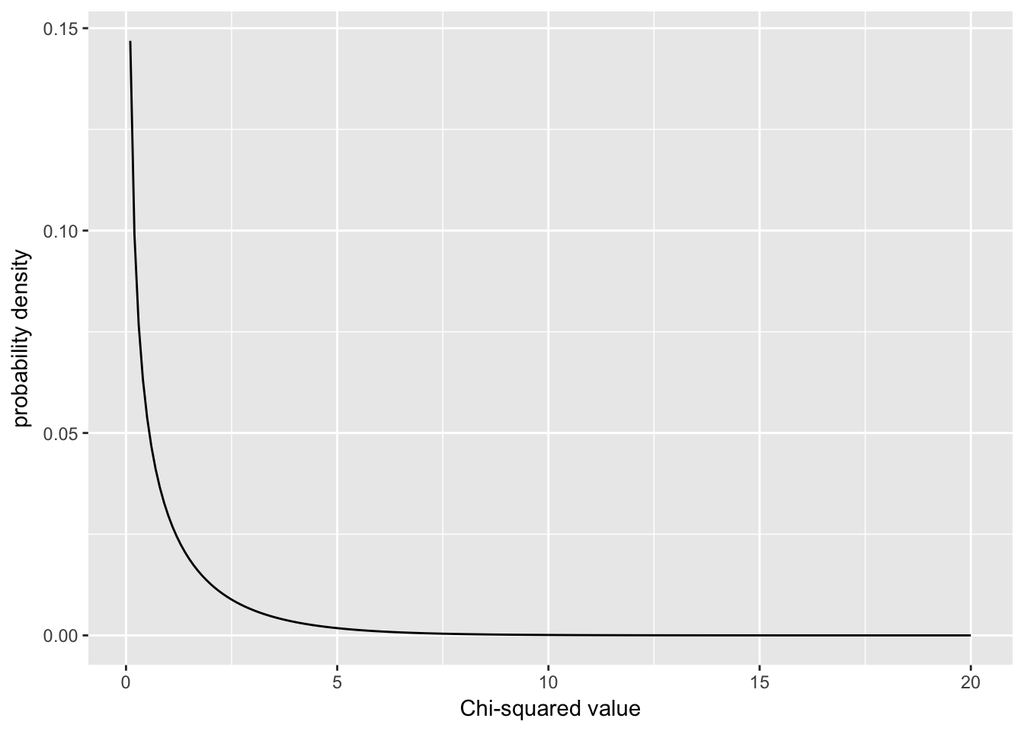

```r
chisqDf=data.frame(seq=seq(0.1,20,0.1)) %>%
  mutate(chisq=dchisq(seq,1))
chisqDf$chisq=chisqDf$chisq/sum(chisqDf$chisq)
ggplot(chisqDf,aes(seq,chisq)) +
  geom_line() + xlab('Chi-squared value') +
  ylab('probability density')
```

The chi-squared distribution is the distribution of the sum of squares of a standard normal random variate. We can see that by sampling a bunch of random normal variates and squaring them and looking at their histogram.

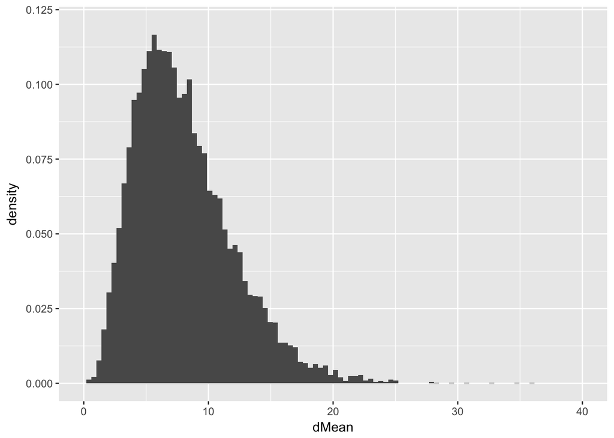

```r
d=replicate(10000,rnorm(8)**2)
dMean=apply(d,2,sum)
csDf=data.frame(x=seq(0.01,40,0.01)) %>%
  mutate(chisq=dchisq(x,8))
ggplot(data.frame(dMean),aes(dMean)) +
  geom_histogram(aes(y=..density..),bins=100) +
  xlim(0,40) + ylim(0,.12)
```

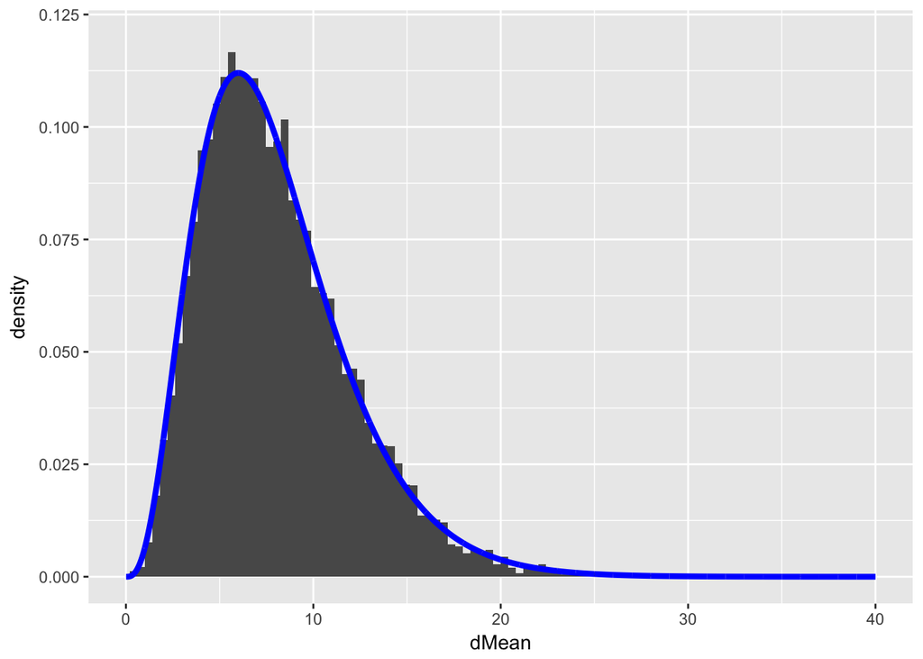

```r
ggplot(data.frame(dMean),aes(dMean)) +
  geom_histogram(aes(y=..density..),bins=100) +
  geom_line(data=csDf,aes(x,chisq),color='blue',size=1.5)+
  xlim(0,40) + ylim(0,.12)
```

We can compute the chi-squared test directly from the contingency table in R using the chisq.test() function:

```r
summaryDf2wayTable = summaryDf2way %>%
  select(-expected,-stdSqDiff) %>%
  spread(searched,n)

summaryDf2wayTable
```

| driver_race | FALSE | TRUE |
| --- | --- | --- |
| Black | 36244 | 1219 |
| White | 239241 | 3108 |

```r
summaryDf2wayTable = summaryDf2wayTable %>%
  select(-driver_race)
chisqTestResult = chisq.test(summaryDf2wayTable,1,correct=FALSE)
chisqTestResult
```

```
##
##  Pearson's Chi-squared test
##
## data:  summaryDf2wayTable
## X-squared = 828.3, df = 1, p-value < 2.2e-16
```

This shows that the observed probabilities would be highly unlikely under the null hypothesis of independence between driver’s race and searching.

Let’s look at the standardized residuals to see which cells seem particularly far from the expected.

```r
summaryDf2way = summaryDf2way %>%
  mutate(stdRes = (n - expected)/sqrt(expected))
summaryDf2way
```

| searched | driver_race | n | expected | stdSqDiff | stdRes |
| --- | --- | --- | --- | --- | --- |
| FALSE | Black | 36244 | 36883.6739 | 11.093870 | -3.330746 |
| TRUE | Black | 1219 | 579.3261 | 706.307991 | 26.576456 |
| FALSE | White | 239241 | 238601.3261 | 1.714922 | 1.309550 |
| TRUE | White | 3108 | 3747.6739 | 109.183105 | -10.449072 |

Now let’s compute the odds and odds ratios

```r
oddsSearchedBlack = summaryDf2way[summaryDf2way$searched==TRUE & summaryDf2way$driver_race=='Black',]$n / summaryDf2way[summaryDf2way$searched==FALSE & summaryDf2way$driver_race=='Black',]$n
oddsSearchedBlack
```

```
## [1] 0.03363315
```

```r
oddsSearchedWhite = summaryDf2way[summaryDf2way$searched==TRUE & summaryDf2way$driver_race=='White',]$n / summaryDf2way[summaryDf2way$searched==FALSE & summaryDf2way$driver_race=='White',]$n
oddsSearchedWhite
```

```
## [1] 0.01299108
```

```r
oddsRatio = oddsSearchedBlack/oddsSearchedWhite
oddsRatio
```

```
## [1] 2.588941
```

Let’s also compute the Bayes factor

```r
library(BayesFactor)
bf = contingencyTableBF(as.matrix(summaryDf2wayTable), sampleType = "jointMulti")
bf
```

```
## Bayes factor analysis
## --------------
## [1] Non-indep. (a=1) : 1.601894e+141 ±0%
##
## Against denominator:
##   Null, independence, a = 1
## ---
## Bayes factor type: BFcontingencyTable, joint multinomial
```

#### Randomization test

Let’s perform random shuffling to assess the distribution of proportions under the null hypothesis of no relations. This is a fairly large dataset so this analysis could take a couple of minutes to complete.

```r
nSamples=500

shuffleChisq = function(stopDataShuffled) {
  stopDataShuffled$driver_race=sample(stopDataShuffled$driver_race)
  csResult = chisq.test(stopDataShuffled$driver_race,stopDataShuffled$searched,correct=FALSE)
  return(csResult$statistic)
}

shuffledChisqValues=replicate(nSamples,shuffleChisq(stopData))
mean(shuffledChisqValues>=chisq)
```

```
## [1] 0
```

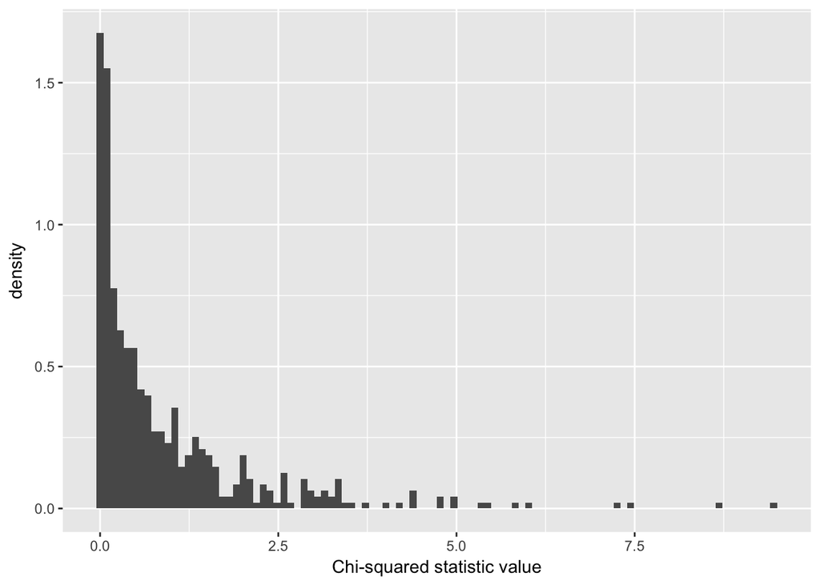

```r
ggplot(data.frame(shuffledChisqValues=shuffledChisqValues),aes(shuffledChisqValues)) +
  geom_histogram(aes(y=..density..),bins=100) +
  xlab('Chi-squared statistic value')
```